# ACT REPORT

## Aim

> The aim of this project is to wrangle WeRateDogs Twitter data to create interesting and trustworthy analyses and visualizations, wrangling (and analyzing and visualizing) the tweet archive of Twitter user @dog_rates, also known as WeRateDogs. WeRateDogs is a Twitter account that rates people's dogs with a humorous comment about the dog.

## Objectives

> In order to achieve the aim set out above, it it importanct that we set objectives to guide us to achieving out aim. The objectives set out are as follows:
> - Gather data
> - Assess data
> - Clean data
> - Analyse data

## Findings

After successfully concluding the gathering, assessing, cleaning and analysis process, the following findings have been made

### 1. Most popular dog breeds

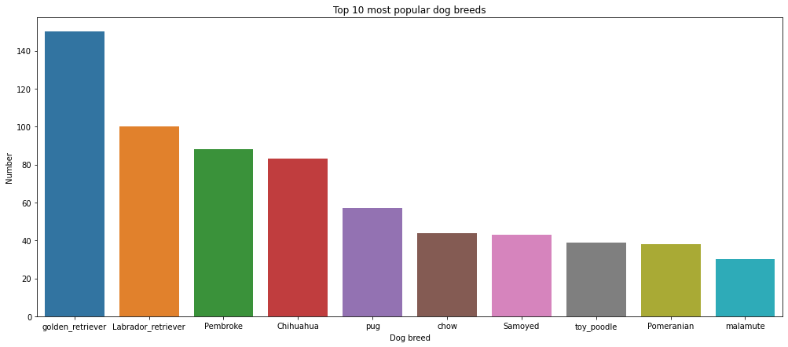

As seen from the chart above, the most popular dog breed present in dataset is the `golden retriever`, appearing more times than any other breed. The `Labrador retriever` and `Pembroke` round up the top three.

### 2. Most liked dog breeds

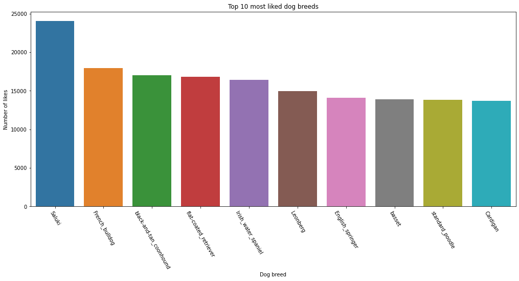

The `Saluki` breed is the most liked(favouted) dog breed averaging about 24k likes. The `French bulldog` and `black and tan coonhound` make up number 2 and 3 with 17.9k and 17k respectively.

### 3. Most retweeted dogs

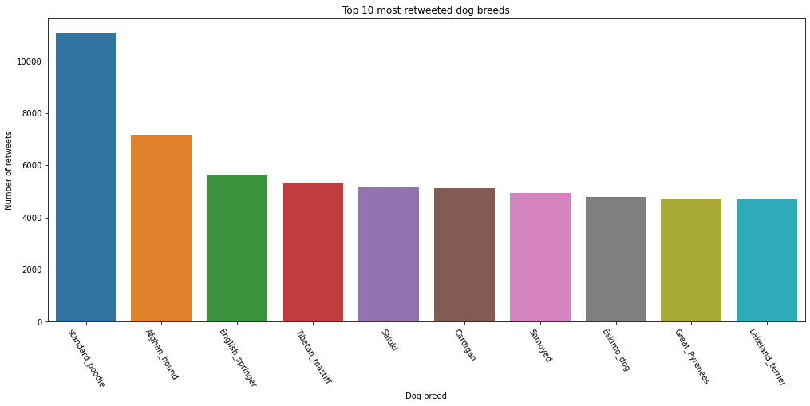

### 4. Most popular dog names

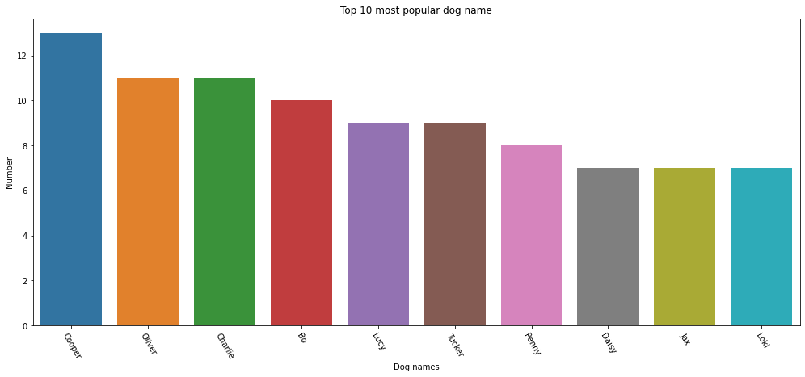

As noted from the image above, Cooper is the most popular dog name with 13 appearances. Oliver and Charlie round up the top three with 11 appearance apiece.

## Conclusion

While the goldon retriever appears to be the most popular, it is the saluki breed that appears to be the most liked by users.